# R Notebook

1. Taking µ0 = (0, . . . , 0) and ??0 = 100Id (vague prior), use JAGS to get an approximation of ??(??|xtrain). Propose a burn-in period B and a length T for the simulated trajectory (burn-in period non-included). Justify your choices. To tell JAGS to use the auxiliary variables approach described above you need to load, before running the jags..model() command, the module glm:

```r
library(MASS)
library(rjags)
load.module('glm')
```

```r
# Load the package rjags
library(rjags)
# Write the model in the file
cat('
model{
for(i in 1:n){
x[i] ~ dbern(p[i])
probit(p[i]) <- sum(theta*Z[i,])
}
theta ~ dmnorm(mu0 ,Omega0)
Omega0<-inverse(Sigma0)
}', file='Spam.bug')
```

```r
spam_data<-list(n=nrow(x_train), x=c(x_train), Z=Z_train,
mu0=rep(0,ncol(Z_train)),Sigma0=diag(100,ncol(Z_train)))
spam_mu<-jags.model('Spam.bug', data=spam_data)
```

Remark: In JAGS you only need to implement the model (2), that is you do not need to implement the model (4) with the auxiliary variables Y1, . . . , Yntrain (the module glm does it for you). Warning: If you do not use the latest version of JAGS (i.e. JAGS 4.3.0) the module glm may not work correctly. To check that JAGS is indeed going to use the auxiliary variables approach described above you can type the command:

```r
list.samplers(spam_mu)
```

```
$`glm::Holmes-Held`
[1] "theta"
```

which should return glm::Holmes-Held if everything works well.

```r
update(spam_mu, n.iter=10000)
```

[output not shown]

```r
sample<-coda.samples(spam_mu,c('theta'), n.iter=20000)
```

[output not shown]

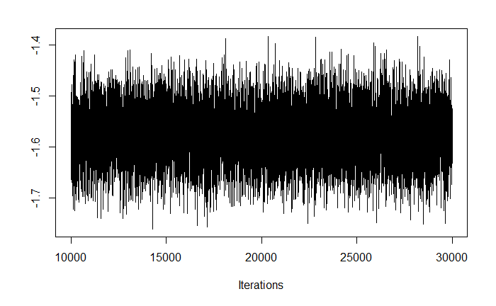

```r
traceplot(sample[,1])
```